# Crises & Correlation

Soumil Jain

11/17/2020

ABSTRACT

A financial crisis is a period of distress for the financial system and the economy as a whole. But what makes a financial crisis, a crisis? Does it imply the defiance of empirical relationships? Let’s have a look.

The data used in this study has been scraped from the FRED Database (by the Federal Reserve) using the Quantmod package in R. The following datasets have been extracted from FRED:

GOLDAMGBD228NLBM (Gold USD/Troy Ounce)

DCOILWTICO (WTI Oil/Barrel)

DGS10 (10 Year Treasury Constant Maturity Rate)

VIXCLS (CBOE VIX)

DFF (Effective Fed Funds Rate)

WILLREITIND (Wilshire US REIT)

DAA (Moody’s Seasoned Aaa Corporate Bond Yield)

DEXJPUS (Japanese Yen vs USD)

DEXUSUK (USD VS BRITISH POUND)

DTB3 (3-Month Treasury Bill: Secondary Market Rate)

Besides, data for S&P 500 has been extracted from Yahoo Finance using the same package.

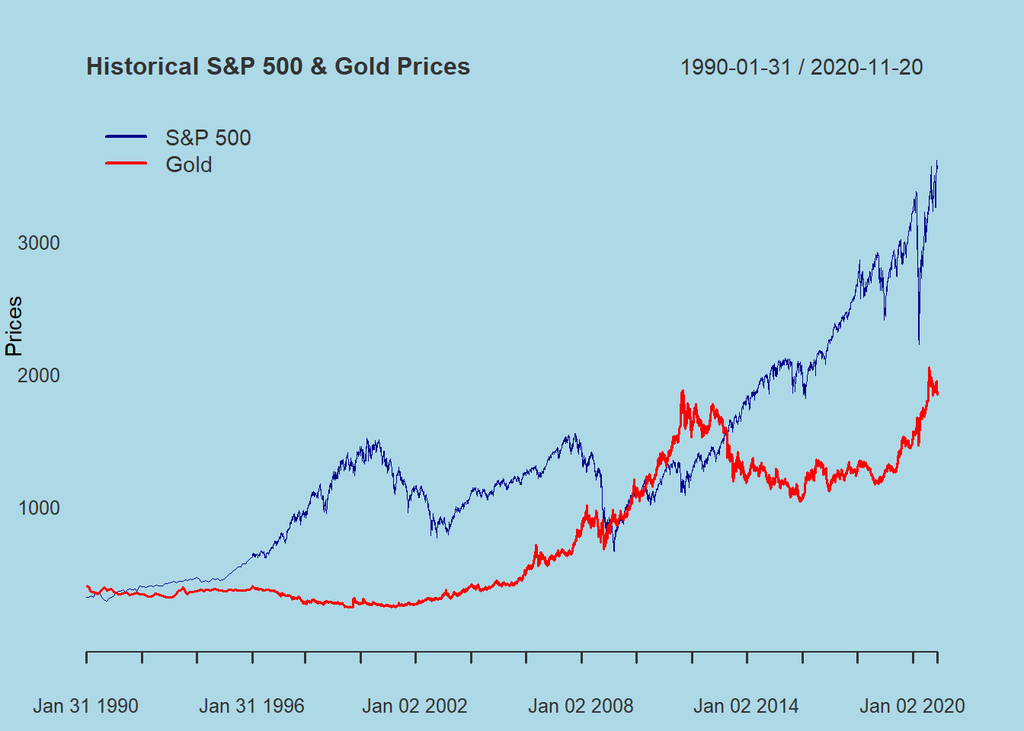

The following time series graph plots the Historical S&P 500 (Equities) and Gold Prices. Both of these asset classes have given phenomenal compounded returns over the years.

Gold prices mentioned here is the USD price per troy ounce of Gold.

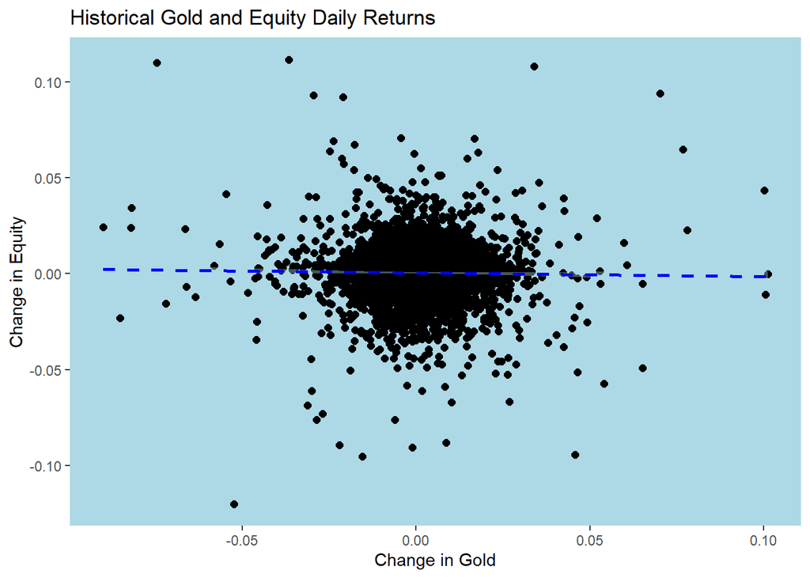

Here is a summary of a regression model on Gold Equity daily changes.

```
##
## Call:
## lm(formula = change$Gold ~ change$Equity)
##
## Residuals:
##       Min        1Q    Median        3Q       Max
## -0.090148 -0.005397 -0.000118  0.005381  0.100900
##
## Coefficients:
##                 Estimate Std. Error t value Pr(>|t|)
## (Intercept)    0.0003161  0.0001453   2.176   0.0296 *
## change$Equity -0.0150885  0.0112482  -1.341   0.1798
## ---
## Signif. codes:  0 '***' 0.001 '**' 0.01 '*' 0.05 '.' 0.1 ' ' 1
##
## Residual standard error: 0.01136 on 6126 degrees of freedom
## Multiple R-squared:  0.0002936,  Adjusted R-squared:  0.0001305
## F-statistic: 1.799 on 1 and 6126 DF,  p-value: 0.1798
```

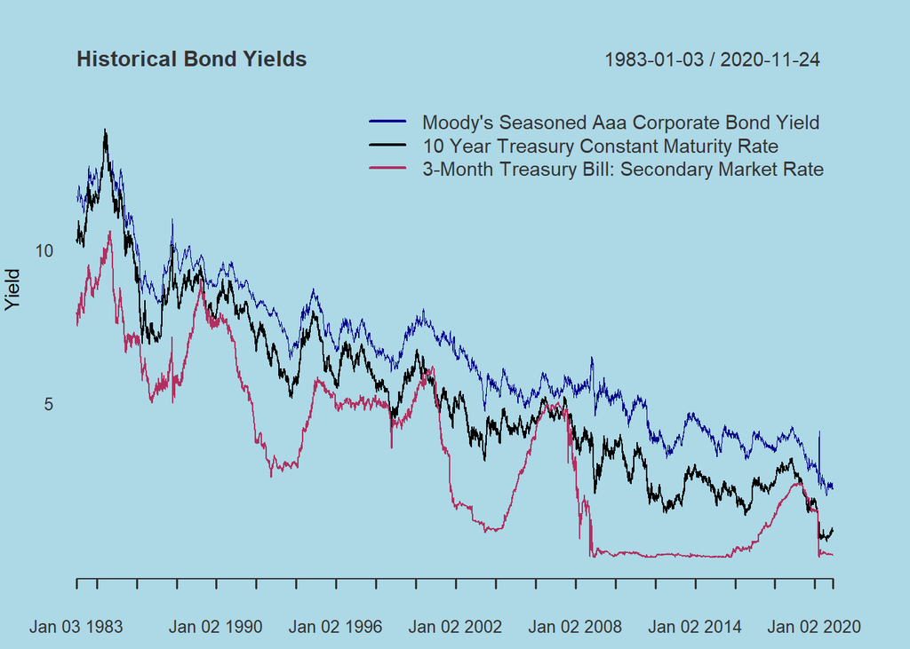

The chart above plots the Yields Corporate Bonds, Long Term Treasuries and Short Term Government Securities.

The yield of a Fixed income security is rate of interest with the respect to the market value. This is slightly different from the Coupon rate which is the rate of interest with respect to the Face Value.

Moody’s Seasoned Aaa Corporate Bond Yield has been used as a gauge Corporate Bond Yields. The 10 Year Bonds and the 3 month Bills issued by the U.S. Treasury have been used to measure the Long term and Short term Treasury Yields respectively.

The graph clearly points out towards the decreasing tendency of Bond yields over the years.

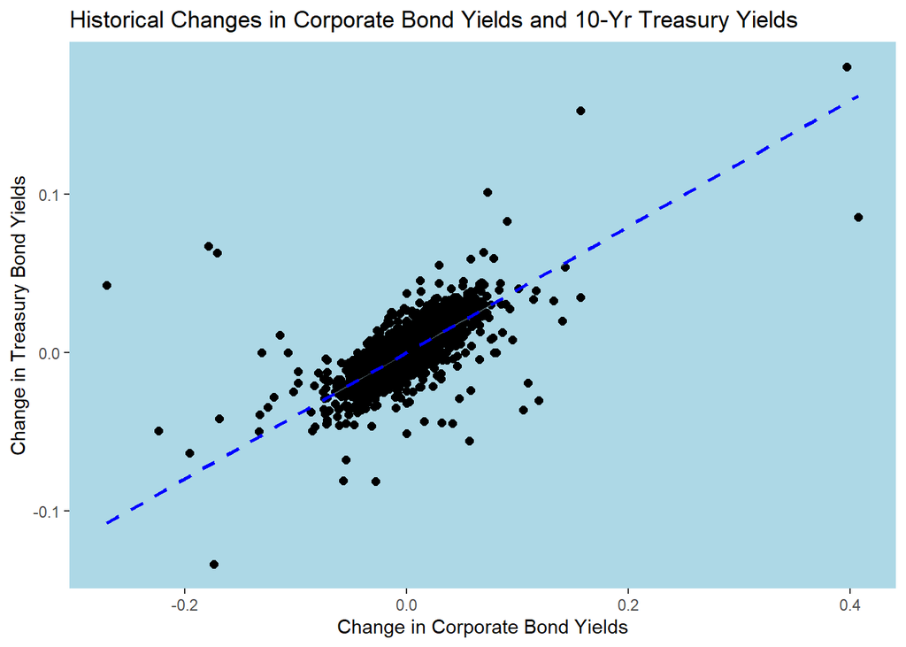

This scatterplot marks the Daily Percentage changes in 10 Year Treasuries on the y-axis and the Corporate Bond Yield on the x-axis.

The dashed dark blue line is the line of best fit (y~x) between the two variables. It clearly reflects of a positive relationship between these rates.

Here are the regression stats for Corporate Bond Yields and Treasury Yields Daily changes

```
##
## Call:
## lm(formula = yieldschange$DAAA ~ yieldschange$DGS10)
##
## Residuals:
##       Min        1Q    Median        3Q       Max
## -0.078248 -0.002549  0.000029  0.002430  0.150100
##
## Coefficients:
##                      Estimate Std. Error t value Pr(>|t|)
## (Intercept)        -8.904e-05  6.745e-05   -1.32    0.187
## yieldschange$DGS10  3.983e-01  3.594e-03  110.80   <2e-16 ***
## ---
## Signif. codes:  0 '***' 0.001 '**' 0.01 '*' 0.05 '.' 0.1 ' ' 1
##
## Residual standard error: 0.006565 on 9471 degrees of freedom
## Multiple R-squared:  0.5645, Adjusted R-squared:  0.5645
## F-statistic: 1.228e+04 on 1 and 9471 DF,  p-value: < 2.2e-16
```

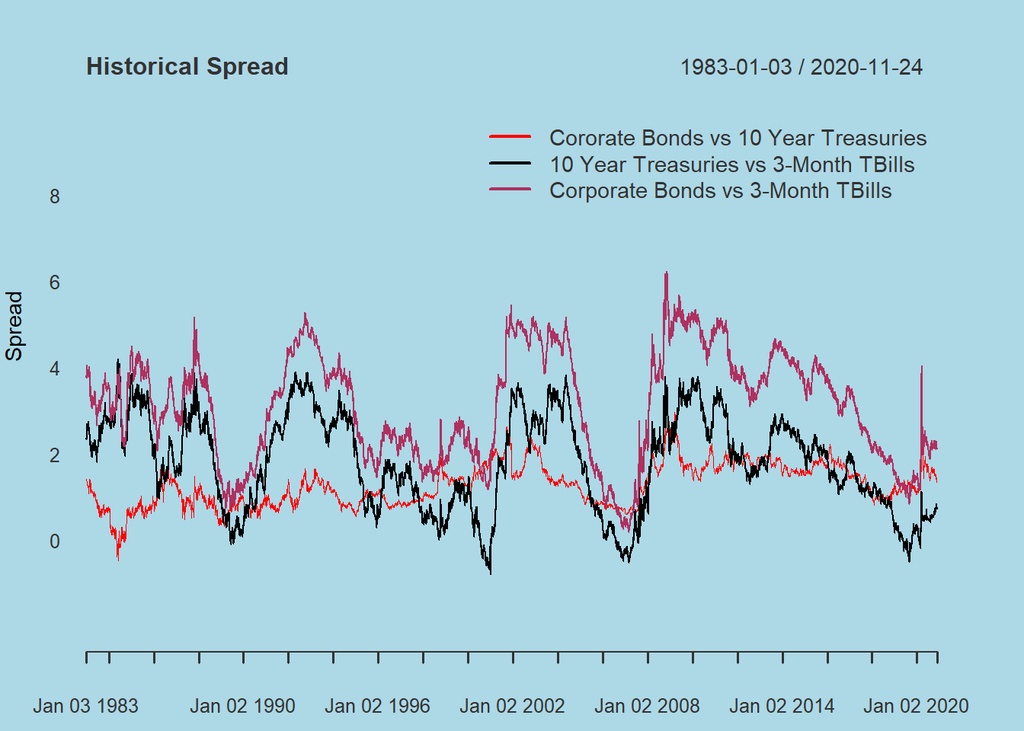

Spread implies the difference between the Interest Rates. The chart here plots spreads as mentioned in the Legend. Historically, this heirarchy of is spotted in the yields:

Corporate > TBonds > Tbills

It must be noted that a flip in the TBonds and TBills, as seen around 2000-01, 2007-08 and 2019, is an indication of an upcoming financial turmoil. The 2000-01 inverse was followed by the dot com bubble, the 2007-08 by the Global Financial Crisis and the 2019 one by the Covid crisis. But wait, how could have the markets predicted this crisis that emerged out of a pandemic? Guess, we’ll never know!

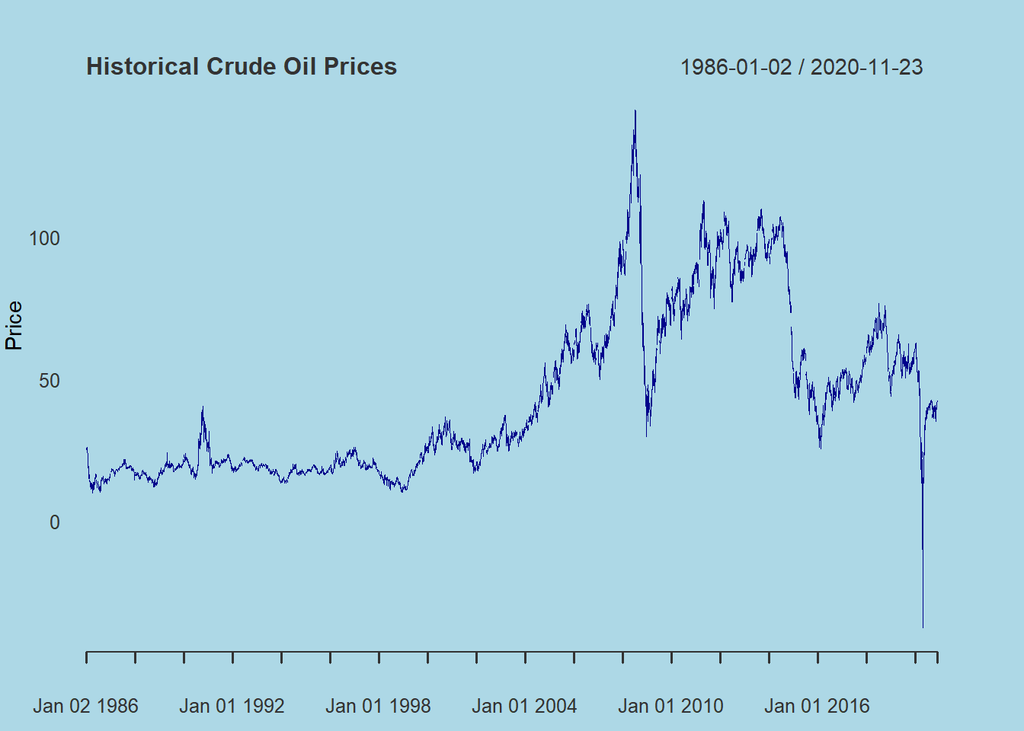

The chart here plots the historical Western Texas Intermidiate (wTI) Crude Oil Spot Rates per Barrel. There has been great fluctuation in oil prices over the years.

Note that the Oil Prices went to negative USD 38 during the Covid Pandemic. Technically, the buyer was buying paid USD 38 for buying a barrel of Oil. Crazy things happen during crises!

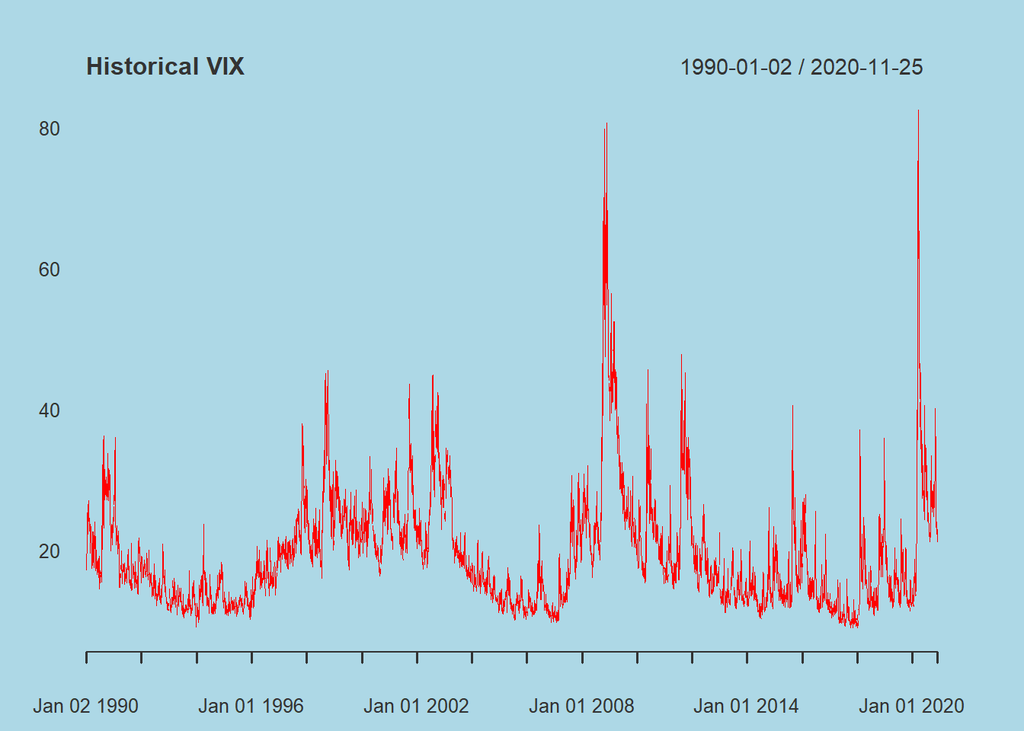

VIX is an indication for the Volatility in the financial markets. Historically, volatility has seen to rise to extraordinary levels during crises. As seen in the chart, the VIX score tops during GFC 2007-09 and during COVID 2020.

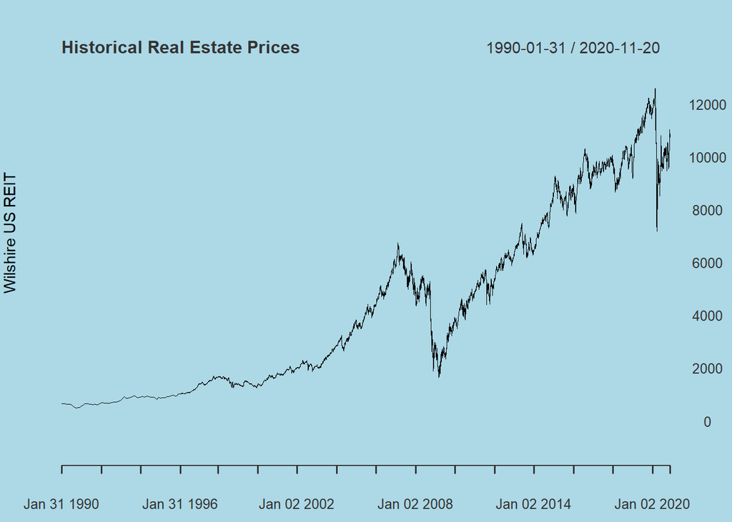

The chart above plots the Willshire US REIT market value over time. A Real Estate Investment Trust , or REIT, is a company that owns, and in most cases operates, income-producing real estate. REITs own many types of commercial real estate, ranging from office and apartment buildings to warehouses, hospitals, shopping centers, hotels and commercial forests.

The GFC 2007-08 was triggered due to the Sub-prime Mortgage crises. As seen in the graph, Real estate prices in the US soared to extraordinary levels which couldn’t be sustained for long and thus, proved to be a bubble.

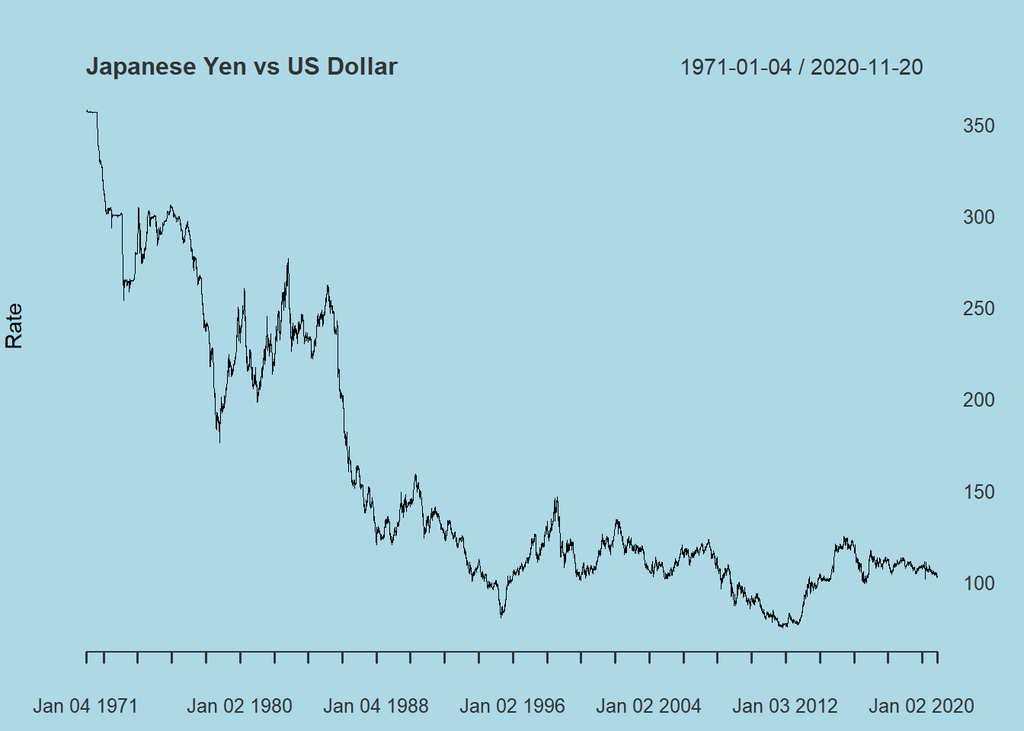

This chart plots the exchange rate between Japanese Yen and the US Dollar. The Japanese Yen has appraciated vis-a-vis US Dollar over the years. Back in 1970s, it would require 350 odd units of Yen to acquire a US dollar. However, as per the present conversion rate, it cost only about 100 JPY to buy a dollar.

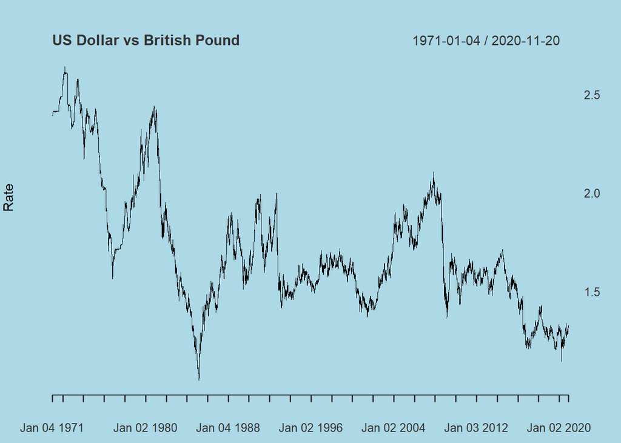

The above graph plots the exchange rate between the US Dollar and the British Pound. AS opposed to the earlier series, this one shows the amount of USD required to acquire one pound. And clearly, the US Dollar has grown in value relative to the British Pound.

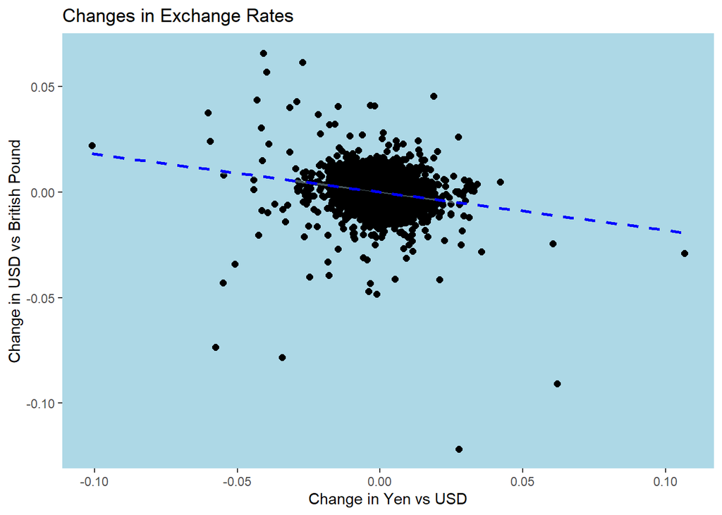

This scatterplot plots the changes in the two foreign exchange rates - JPY vs USD and USD vs UK.

Running a regression and plotting the line of best fit, indicates an imperfect negative correlation between the two exchange rates, which is absolutely understandable, keeping in mind the fact that the first rate is JPY vs USD and not USD vs JPY.

The following summary shows the regression metrics for the two exchange rates.

```
##
## Call:
## lm(formula = change$JPvUS ~ change$USvUK)
##
## Residuals:
##       Min        1Q    Median        3Q       Max
## -0.096021 -0.003285  0.000159  0.003597  0.100121
##
## Coefficients:
##                Estimate Std. Error t value Pr(>|t|)
## (Intercept)  -2.907e-05  9.398e-05  -0.309    0.757
## change$USvUK -2.209e-01  1.386e-02 -15.941   <2e-16 ***
## ---
## Signif. codes:  0 '***' 0.001 '**' 0.01 '*' 0.05 '.' 0.1 ' ' 1
##
## Residual standard error: 0.007357 on 6126 degrees of freedom
## Multiple R-squared:  0.03983,    Adjusted R-squared:  0.03967
## F-statistic: 254.1 on 1 and 6126 DF,  p-value: < 2.2e-16
```

|  | Equity | Gold | Bonds | TBonds | Oil | VIX | FFR | REIT | JPvUS | USvUK |
| --- | --- | --- | --- | --- | --- | --- | --- | --- | --- | --- |
| Average Change | 0.0004718998 | 0.000308974 | -0.0001553562 | -0.0001164721 | -3.404775e-05 | 2.559671e-03 | 0.0027577772 | 0.0006053281 | -2.576263e-05 | -1.496992e-05 |
| Std. Dev. of Change | 0.0129059090 | 0.011363794 | 0.0122186194 | 0.0229861438 | 5.150715e-02 | 7.406570e-02 | 0.0882798874 | 0.0177679324 | 7.507208e-03 | 6.781356e-03 |
| Downside Deviation | 0.0090349132 | 0.007844173 | 0.0083585556 | 0.0156973555 | 4.609586e-02 | 4.330804e-02 | 0.0492038383 | 0.0122720717 | 5.526927e-03 | 5.018068e-03 |
| Minimum Change | -0.1198405525 | -0.090197996 | -0.1334951456 | -0.2702702703 | -3.019661e+00 | -3.266504e-01 | -0.7727272727 | -0.1976218666 | -1.009317e-01 | -1.216976e-01 |
| Maximum Change | 0.1115878548 | 0.101217391 | 0.1805555556 | 0.4074074074 | 5.308642e-01 | 1.155979e+00 | 1.4666666667 | 0.1898270968 | 1.065203e-01 | 6.590258e-02 |
| Skewness | -0.0569155478 | 0.086299584 | 0.8122117719 | 1.2612942330 | -3.471053e+01 | 1.886869e+00 | 4.1886369366 | 0.1926483911 | -4.814519e-01 | -1.502093e+00 |
| Geometric Mean | 0.0003885421 | 0.000244430 | -0.0002296208 | -0.0003782128 | NaN | -1.104728e-05 | -0.0007564294 | 0.0004473535 | -5.402321e-05 | -3.813714e-05 |
| Kurtosis | 10.2488583791 | 9.284632010 | 18.7143173491 | 41.7199345446 | 1.985620e+03 | 1.562232e+01 | 57.0724400694 | 21.7398341876 | 1.942924e+01 | 3.503481e+01 |

The above table presents some summary statistics of a few asset classes discussed in this project earlier.

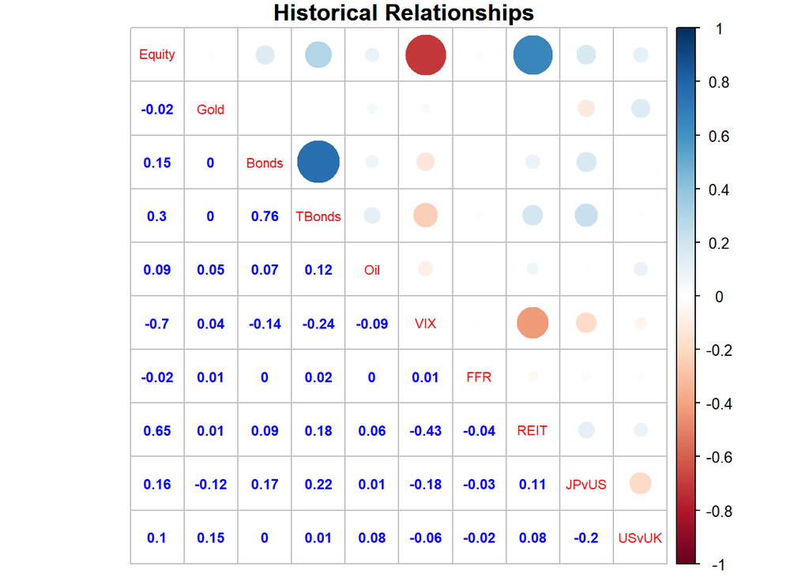

The correlogram visualizes a correlation matrix of correlations between the daily changes in various asset classes and financial parameters.

Note : The FFR mentioned here is the Effective Federal Funds Rate.

Having looked at the empirical relationships, let’s move on to specific crises periods.

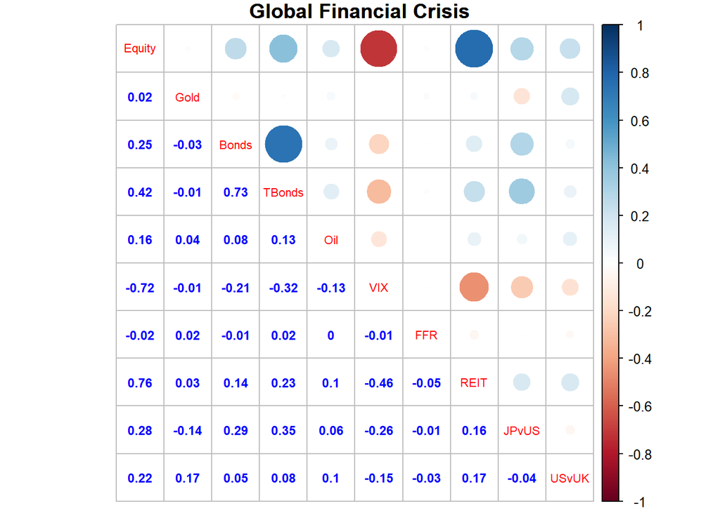

This correlogram visualizes correlations during the period of Global Financial Crisis (1st July, 2007 to 31st June, 2009).

Some differences can be spotted in this visualization as compared to the Historical Correlations one. A generalist interpretation is the strengthening of already existing relationships.

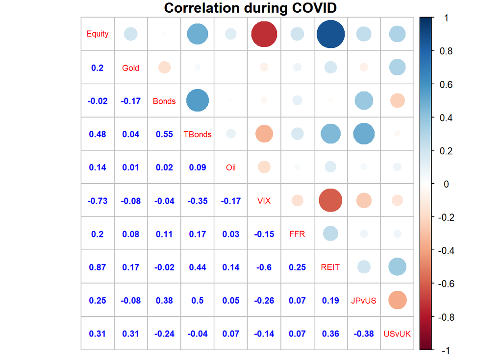

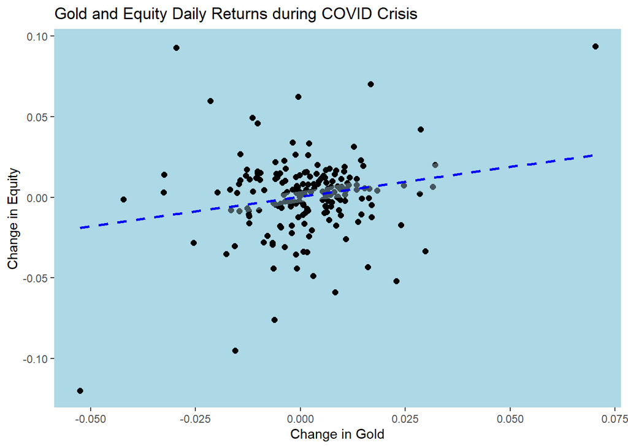

```
##
## Call:
## lm(formula = covidchange$Gold ~ covidchange$Equity)
##
## Residuals:
##       Min        1Q    Median        3Q       Max
## -0.042923 -0.006416  0.000023  0.007351  0.059379
##
## Coefficients:
##                     Estimate Std. Error t value Pr(>|t|)
## (Intercept)        0.0008995  0.0009306   0.967  0.33499
## covidchange$Equity 0.1063512  0.0381074   2.791  0.00579 **
## ---
## Signif. codes:  0 '***' 0.001 '**' 0.01 '*' 0.05 '.' 0.1 ' ' 1
##
## Residual standard error: 0.01292 on 191 degrees of freedom
## Multiple R-squared:  0.03918,    Adjusted R-squared:  0.03415
## F-statistic: 7.789 on 1 and 191 DF,  p-value: 0.005791
```

And one of the most unique attributes of this economic crises brought along by the Covid-19 Pandemic, is the unidirectional movement between Equities and Gold. THis scatter plot exhibits a positive relation between the two asset classes.

Historical Correlation = -0.02

Correlation during GFC = 0.02

Correlation during Covid = 0.2

Both equities and gold are moving up in the same direction. Gold is going up more because whenever there are times of uncertainty and also with the kind of massive stimulus that has been injected into the economies worldwide, that is likely to debase the currencies, the printed money. That is what has been happening with every crisis - we are printing more and more money. Interest rates are becoming low to negative and therefore gold, while it is an unproductive investment, but as a store of value it keeps going up.

When you have this amount of money printing happening around the world, gold is an asset that people go to. As far as equities is concerned, it is the only productive assets which can still give you a positive yield or return because clearly long term interest rates are headed down and are likely to remain down for a long, long period of time.

Debt investments are unlikely to give you real returns and real returns can only be had from equities because inherently companies generate cash flows and profitability and they tend to beat inflation and nominal growth rates. So it is more a reflection of the fact that in one case, the asset class like gold is responding to massive liquidity and the fact that inflation expectations are very very low, on the other hand equities is an asset class which reflects the ability to give some kind of a absolute return over long periods of time because companies tend to generate cash flows and profitability which protect your capital and grow it over a period of time.

Everything is fair in love, war and crisis! Prices of real assets can drop to sub-zero levels and asset classes can defy all empirical relationships.